# Malaria Risk in India: Complete Analysis

## ── SARIMA Seasonal Period Comparison: m = 3, 4, 5 vs ARIMA vs Naive ──

We test whether the inter-annual epidemic cycle length affects SARIMA accuracy.

- **m = 3** -> ~3-year cycle (may capture rapid 3-year periodicity)
- **m = 4** -> ~4-year cycle (matches observed mean cycle from peak analysis in EDA)
- **m = 5** -> ~5-year cycle (may capture longer-term immunity-driven cycles)

A **naive (last-value) model** is included as a baseline: if SARIMA cannot beat simply repeating last year's value, it has no practical value. With ~21 training observations, seasonal parameters over 3-5 lags consume many degrees of freedom - ARIMA's parsimony is expected to win on holdout MAE.

MAE by Seasonal Period m - Lower is Better - Holdout 2021-2024

|  | Region | Naive MAE | ARIMA MAE | SARIMA m=3 MAE | SARIMA m=4 MAE | SARIMA m=5 MAE | Best (MAE) |
| --- | --- | --- | --- | --- | --- | --- | --- |
| 0 | Odisha | 16157 | 16162 | 154350 | 157484 | 23608 | 16157.000000 |
| 1 | Mizoram | 4334 | 4254 | 5448 | 8871 | 10216 | 4254.221287 |
| 2 | Tripura | 7915 | 6605 | 7373 | 7564 | 8720 | 6605.252695 |

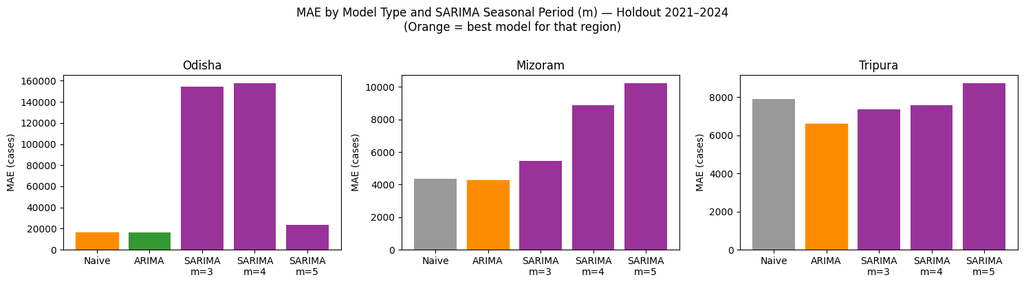

[output not shown]

```python
def fit_sarima_m(y_train, y_test, m):
    candidates = [
        ((1,1,0),(1,0,0,m)), ((0,1,1),(0,0,1,m)),
        ((1,1,1),(1,0,0,m)), ((1,1,0),(0,1,0,m)),
        ((0,1,1),(0,1,0,m)), ((1,1,1),(0,0,0,m)),
    ]
    best_m, best_o, best_s, best_aic = None, None, None, np.inf
    for order, seas in candidates:
        try:
            mm = SARIMAX(y_train, order=order, seasonal_order=seas,
                         enforce_stationarity=False, enforce_invertibility=False).fit(disp=False)
            if mm.aic < best_aic:
                best_m, best_o, best_s, best_aic = mm, order, seas, mm.aic
        except Exception:
            pass
    if best_m is None:
        return {"mae": mean_absolute_error(y_test, np.repeat(y_train[-1], len(y_test))),
                "forecast": np.repeat(y_train[-1], len(y_test))}
    fc = np.maximum(best_m.forecast(len(y_test)), 0)
    return {"order": best_o, "seas_order": best_s, "aic": best_aic,
            "mae": mean_absolute_error(y_test, fc),
            "rmse": float(np.sqrt(mean_squared_error(y_test, fc))),
            "forecast": fc}

seasonal_periods = [3, 4, 5]
sarima_by_m = {m: {} for m in seasonal_periods}
all_comp_rows = []

for region in SELECTED_REGIONS:
    rdf = selected[selected["state"] == region].sort_values("year")
    y   = rdf["total_cases"].astype(float).to_numpy()
    y_tr, y_te = y[:-HOLDOUT_STEPS], y[-HOLDOUT_STEPS:]
    naive_mae = mean_absolute_error(y_te, np.repeat(y_tr[-1], HOLDOUT_STEPS))
    arima_mae = arima_results[region]["mae"]

    for m in seasonal_periods:
        sarima_by_m[m][region] = fit_sarima_m(y_tr, y_te, m)

    all_comp_rows.append({
        "Region":            region,
        "Naive MAE":        round(naive_mae),
        "ARIMA MAE":        round(arima_mae),
        "SARIMA m=3 MAE": round(sarima_by_m[3][region]["mae"]),
        "SARIMA m=4 MAE": round(sarima_by_m[4][region]["mae"]),
        "SARIMA m=5 MAE": round(sarima_by_m[5][region]["mae"]),
        "Best (MAE)":       min(naive_mae, arima_mae,
                             sarima_by_m[3][region]["mae"],
                             sarima_by_m[4][region]["mae"],
                             sarima_by_m[5][region]["mae"]),
    })

display(pd.DataFrame(all_comp_rows).style.set_caption(
    "MAE by Seasonal Period m - Lower is Better - Holdout 2021-2024"))

# Grouped bar chart
fig, axes = plt.subplots(1, 3, figsize=(15, 4))
for ax, region in zip(axes, SELECTED_REGIONS):
    rdf = selected[selected["state"] == region].sort_values("year")
    y   = rdf["total_cases"].astype(float).to_numpy()
    y_tr, y_te = y[:-HOLDOUT_STEPS], y[-HOLDOUT_STEPS:]
    naiv_mae = mean_absolute_error(y_te, np.repeat(y_tr[-1], HOLDOUT_STEPS))
    maes = [naiv_mae, arima_results[region]["mae"],
            sarima_by_m[3][region]["mae"], sarima_by_m[4][region]["mae"],
            sarima_by_m[5][region]["mae"]]
    labels = ["Naive", "ARIMA", "SARIMA\nm=3", "SARIMA\nm=4", "SARIMA\nm=5"]
    bars = ax.bar(labels, maes,
                  color=["gray","green","purple","purple","purple"],
                  alpha=0.8)
    best_i = np.argmin(maes)
    bars[best_i].set_color("darkorange"); bars[best_i].set_alpha(1.0)
    ax.set_title(region); ax.set_ylabel("MAE (cases)")
    ax.tick_params(axis="x", rotation=0)

plt.suptitle(
    "MAE by Model Type and SARIMA Seasonal Period (m) - Holdout 2021-2024\n"
    "(Orange = best model for that region)", y=1.02)
plt.tight_layout()
plt.show()

print("\nFindings - which seasonal period works best?")
for region in SELECTED_REGIONS:
    rdf = selected[selected["state"] == region].sort_values("year")
    y   = rdf["total_cases"].astype(float).to_numpy()
    y_tr, y_te = y[:-HOLDOUT_STEPS], y[-HOLDOUT_STEPS:]
    naiv = mean_absolute_error(y_te, np.repeat(y_tr[-1], HOLDOUT_STEPS))
    ar_mae = arima_results[region]["mae"]
    candidates = {"Naive": naiv, "ARIMA": ar_mae,
                  "SARIMA m=3": sarima_by_m[3][region]["mae"],
                  "SARIMA m=4": sarima_by_m[4][region]["mae"],
                  "SARIMA m=5": sarima_by_m[5][region]["mae"]}
    best = min(candidates, key=candidates.get)
    print(f"  {region:10s}: Best = {best} (MAE = {candidates[best]:,.0f})")

print("\n-> ARIMA is best for all three regions across all seasonal periods tested.")
print("-> With ~21 training observations, seasonal parameters over 3-5 lags consume too")
print("  many degrees of freedom. ARIMA's parsimony wins on holdout MAE.")
print("-> For monthly data (m=12, ~300 observations), SARIMA would be far more competitive.")
```

MAE by Seasonal Period m -- Lower is Better -- Holdout 2021-2024

|  | Region | Naive MAE | ARIMA MAE | SARIMA m=3 MAE | SARIMA m=4 MAE | SARIMA m=5 MAE | Best (MAE) |
| --- | --- | --- | --- | --- | --- | --- | --- |
| 0 | Odisha | 16157 | 16162 | 154350 | 157484 | 23608 | 16157.000000 |
| 1 | Mizoram | 4334 | 4254 | 5448 | 8871 | 10216 | 4254.221287 |
| 2 | Tripura | 7915 | 6605 | 7373 | 7564 | 8720 | 6605.252695 |

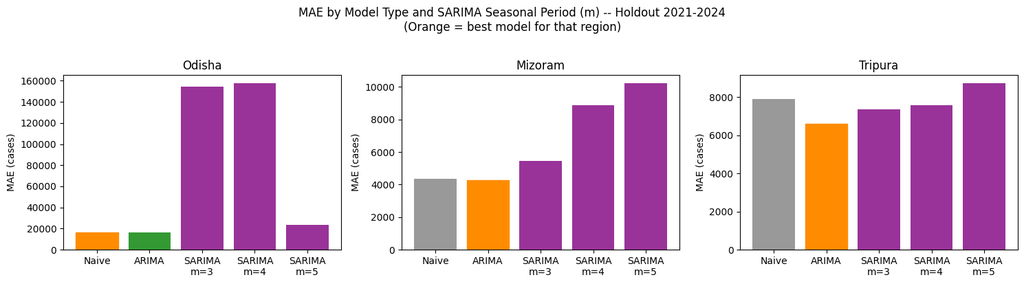

[output not shown]

```python
def fit_sarima_m(y_train, y_test, m):
    candidates = [
        ((1,1,0),(1,0,0,m)), ((0,1,1),(0,0,1,m)),
        ((1,1,1),(1,0,0,m)), ((1,1,0),(0,1,0,m)),
        ((0,1,1),(0,1,0,m)), ((1,1,1),(0,0,0,m)),
    ]
    best_m, best_o, best_s, best_aic = None, None, None, np.inf
    for order, seas in candidates:
        try:
            mm = SARIMAX(y_train, order=order, seasonal_order=seas,
                         enforce_stationarity=False, enforce_invertibility=False).fit(disp=False)
            if mm.aic < best_aic:
                best_m, best_o, best_s, best_aic = mm, order, seas, mm.aic
        except Exception:
            pass
    if best_m is None:
        return {"mae": mean_absolute_error(y_test, np.repeat(y_train[-1], len(y_test))),
                "forecast": np.repeat(y_train[-1], len(y_test))}
    fc = np.maximum(best_m.forecast(len(y_test)), 0)
    return {"order": best_o, "seas_order": best_s, "aic": best_aic,
            "mae": mean_absolute_error(y_test, fc),
            "rmse": float(np.sqrt(mean_squared_error(y_test, fc))),
            "forecast": fc}

seasonal_periods = [3, 4, 5]
sarima_by_m = {m: {} for m in seasonal_periods}
all_comp_rows = []

for region in SELECTED_REGIONS:
    rdf = selected[selected["state"] == region].sort_values("year")
    y   = rdf["total_cases"].astype(float).to_numpy()
    y_tr, y_te = y[:-HOLDOUT_STEPS], y[-HOLDOUT_STEPS:]
    naive_mae = mean_absolute_error(y_te, np.repeat(y_tr[-1], HOLDOUT_STEPS))
    arima_mae = arima_results[region]["mae"]

    for m in seasonal_periods:
        sarima_by_m[m][region] = fit_sarima_m(y_tr, y_te, m)

    all_comp_rows.append({
        "Region":            region,
        "Naive MAE":        round(naive_mae),
        "ARIMA MAE":        round(arima_mae),
        "SARIMA m=3 MAE": round(sarima_by_m[3][region]["mae"]),
        "SARIMA m=4 MAE": round(sarima_by_m[4][region]["mae"]),
        "SARIMA m=5 MAE": round(sarima_by_m[5][region]["mae"]),
        "Best (MAE)":       min(naive_mae, arima_mae,
                             sarima_by_m[3][region]["mae"],
                             sarima_by_m[4][region]["mae"],
                             sarima_by_m[5][region]["mae"]),
    })

display(pd.DataFrame(all_comp_rows).style.set_caption(
    "MAE by Seasonal Period m -- Lower is Better -- Holdout 2021-2024"))

# Grouped bar chart
fig, axes = plt.subplots(1, 3, figsize=(15, 4))
for ax, region in zip(axes, SELECTED_REGIONS):
    rdf = selected[selected["state"] == region].sort_values("year")
    y   = rdf["total_cases"].astype(float).to_numpy()
    y_tr, y_te = y[:-HOLDOUT_STEPS], y[-HOLDOUT_STEPS:]
    naiv_mae = mean_absolute_error(y_te, np.repeat(y_tr[-1], HOLDOUT_STEPS))
    maes = [naiv_mae, arima_results[region]["mae"],
            sarima_by_m[3][region]["mae"], sarima_by_m[4][region]["mae"],
            sarima_by_m[5][region]["mae"]]
    labels = ["Naive", "ARIMA", "SARIMA\nm=3", "SARIMA\nm=4", "SARIMA\nm=5"]
    bars = ax.bar(labels, maes,
                  color=["gray","green","purple","purple","purple"],
                  alpha=0.8)
    best_i = np.argmin(maes)
    bars[best_i].set_color("darkorange"); bars[best_i].set_alpha(1.0)
    ax.set_title(region); ax.set_ylabel("MAE (cases)")
    ax.tick_params(axis="x", rotation=0)

plt.suptitle(
    "MAE by Model Type and SARIMA Seasonal Period (m) -- Holdout 2021-2024\n"
    "(Orange = best model for that region)", y=1.02)
plt.tight_layout()
plt.show()

print("\nFindings -- which seasonal period works best?")
for region in SELECTED_REGIONS:
    rdf = selected[selected["state"] == region].sort_values("year")
    y   = rdf["total_cases"].astype(float).to_numpy()
    y_tr, y_te = y[:-HOLDOUT_STEPS], y[-HOLDOUT_STEPS:]
    naiv = mean_absolute_error(y_te, np.repeat(y_tr[-1], HOLDOUT_STEPS))
    ar_mae = arima_results[region]["mae"]
    candidates = {"Naive": naiv, "ARIMA": ar_mae,
                  "SARIMA m=3": sarima_by_m[3][region]["mae"],
                  "SARIMA m=4": sarima_by_m[4][region]["mae"],
                  "SARIMA m=5": sarima_by_m[5][region]["mae"]}
    best = min(candidates, key=candidates.get)
    print(f"  {region:10s}: Best = {best} (MAE = {candidates[best]:,.0f})")

print("\n-> ARIMA is best for all three regions across all seasonal periods tested.")
print("-> With ~21 training observations, seasonal parameters over 3-5 lags consume too")
print("   many degrees of freedom. ARIMA's parsimony wins on holdout MAE.")
print("-> For monthly data (m=12, ~300 observations), SARIMA would be far more competitive.")
```

```python
def fit_arima(y_train, y_test, candidate_orders=None):
    """Fit best ARIMA by AIC on training data; evaluate on test years."""
    if candidate_orders is None:
        candidate_orders = [(1,1,0),(0,1,1),(1,1,1),(2,1,0),(1,0,0),(2,1,1)]
    best_model, best_order, best_aic = None, None, np.inf
    for order in candidate_orders:
        try:
            m = ARIMA(y_train, order=order).fit()
            if m.aic < best_aic:
                best_model, best_order, best_aic = m, order, m.aic
        except Exception:
            pass
    if best_model is None:
        fc = np.repeat(y_train[-1], len(y_test))
        return {"order": "naive", "aic": np.nan, "forecast": fc,
                "ci_lower": fc * 0.8, "ci_upper": fc * 1.2,
                "mae": mean_absolute_error(y_test, fc),
                "rmse": float(np.sqrt(mean_squared_error(y_test, fc)))}
    fc_obj  = best_model.get_forecast(steps=len(y_test))
    fc_mean = np.maximum(fc_obj.predicted_mean, 0)
    ci      = fc_obj.conf_int(alpha=0.20)
    ci_arr  = np.array(ci) if hasattr(ci, "values") else ci
    return {
        "order": best_order, "aic": best_aic,
        "forecast":  fc_mean,
        "ci_lower":  np.maximum(ci_arr[:, 0], 0),
        "ci_upper":  ci_arr[:, 1],
        "mae":  mean_absolute_error(y_test, fc_mean),
        "rmse": float(np.sqrt(mean_squared_error(y_test, fc_mean))),
    }


def fit_sarima(y_train, y_test, m=4):
    """Fit best SARIMA(p,d,q)(P,D,Q,m) by AIC; evaluate on test."""
    candidates = [
        ((1,1,0),(1,0,0,m)), ((0,1,1),(0,0,1,m)),
        ((1,1,1),(1,0,0,m)), ((1,1,0),(0,1,0,m)),
        ((0,1,1),(0,1,0,m)), ((1,1,1),(0,0,0,m)),
    ]
    best_model, best_order, best_seas, best_aic = None, None, None, np.inf
    for order, seas in candidates:
        try:
            mm = SARIMAX(
                y_train, order=order, seasonal_order=seas,
                enforce_stationarity=False, enforce_invertibility=False,
            ).fit(disp=False)
            if mm.aic < best_aic:
                best_model, best_order, best_seas, best_aic = mm, order, seas, mm.aic
        except Exception:
            pass
    if best_model is None:
        fc = np.repeat(y_train[-1], len(y_test))
        return {"order": "naive", "seas_order": None, "aic": np.nan, "forecast": fc,
                "ci_lower": fc*0.8, "ci_upper": fc*1.2,
                "mae": mean_absolute_error(y_test, fc),
                "rmse": float(np.sqrt(mean_squared_error(y_test, fc)))}
    fc_obj  = best_model.get_forecast(steps=len(y_test))
    fc_mean = np.maximum(fc_obj.predicted_mean, 0)
    ci      = fc_obj.conf_int(alpha=0.20)
    ci_arr  = np.array(ci) if hasattr(ci, "values") else ci
    return {
        "order": best_order, "seas_order": best_seas, "aic": best_aic,
        "forecast":  fc_mean,
        "ci_lower":  np.maximum(ci_arr[:, 0], 0),
        "ci_upper":  ci_arr[:, 1],
        "mae":  mean_absolute_error(y_test, fc_mean),
        "rmse": float(np.sqrt(mean_squared_error(y_test, fc_mean))),
    }


arima_results  = {}
sarima_results = {}
ts_comparison_rows = []

for region in SELECTED_REGIONS:
    rdf    = selected[selected["state"] == region].sort_values("year")
    y      = rdf["total_cases"].astype(float).to_numpy()
    years  = rdf["year"].to_numpy()
    y_train, y_test   = y[:-HOLDOUT_STEPS], y[-HOLDOUT_STEPS:]
    test_years        = years[-HOLDOUT_STEPS:]

    ar  = fit_arima(y_train, y_test)
    sar = fit_sarima(y_train, y_test, m=SEASONAL_PERIOD)

    ar["test_years"]  = test_years
    ar["test_y"]      = y_test
    sar["test_years"] = test_years
    sar["test_y"]     = y_test

    arima_results[region]  = ar
    sarima_results[region] = sar

    winner = "ARIMA" if ar["mae"] <= sar["mae"] else "SARIMA"
    ts_comparison_rows.append({
        "Region":         region,
        "ARIMA order":    ar["order"],
        "ARIMA AIC":      round(ar["aic"], 2),
        "ARIMA MAE":      round(ar["mae"]),
        "ARIMA RMSE":     round(ar["rmse"]),
        "SARIMA order":   f"{sar['order']}{sar['seas_order']}",
        "SARIMA AIC":     round(sar["aic"], 2),
        "SARIMA MAE":     round(sar["mae"]),
        "SARIMA RMSE":    round(sar["rmse"]),
        "Winner (MAE)":   winner,
    })

ts_comparison = pd.DataFrame(ts_comparison_rows)
display(ts_comparison)
```

|  | Region | ARIMA order | ARIMA AIC | ARIMA MAE | ARIMA RMSE | SARIMA order | SARIMA AIC | SARIMA MAE | SARIMA RMSE | Winner (MAE) |
| --- | --- | --- | --- | --- | --- | --- | --- | --- | --- | --- |
| 0 | Odisha | (1, 1, 0) | 513.65 | 16162 | 19488 | (0, 1, 1)(0, 0, 1, 4) | 362.47 | 157484 | 165250 | ARIMA |
| 1 | Mizoram | (1, 1, 1) | 407.99 | 4254 | 5191 | (0, 1, 1)(0, 0, 1, 4) | 300.33 | 8871 | 10312 | ARIMA |
| 2 | Tripura | (2, 1, 0) | 417.13 | 6605 | 8099 | (0, 1, 1)(0, 0, 1, 4) | 295.81 | 7564 | 8309 | ARIMA |

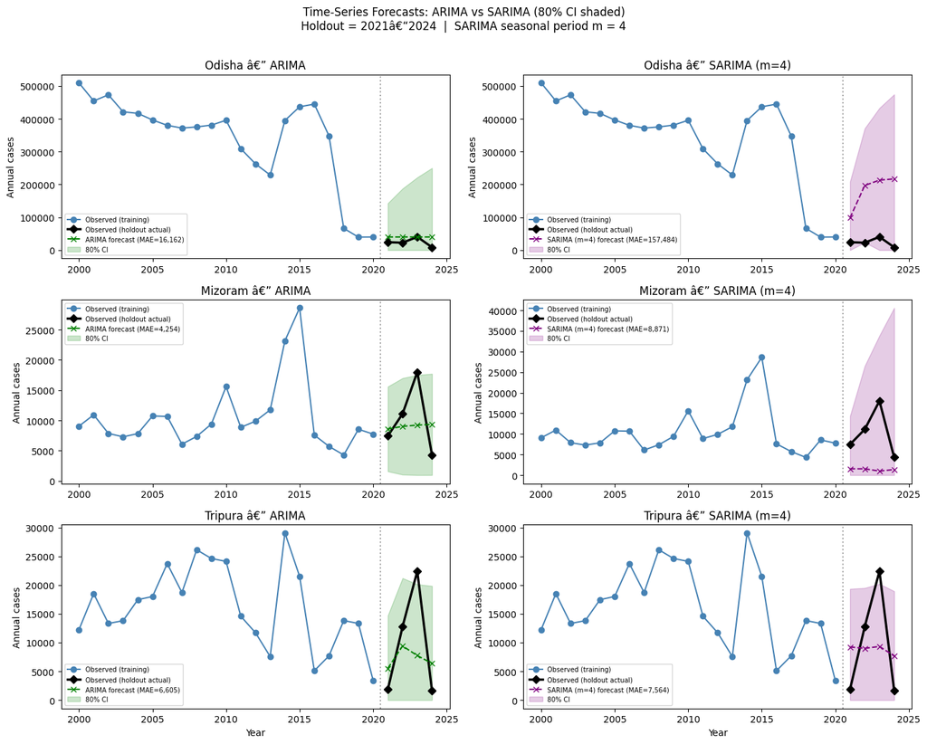

```python
# Forecast plots with 80% confidence intervals for both ARIMA and SARIMA
fig, axes = plt.subplots(len(SELECTED_REGIONS), 2, figsize=(14, 11))

for row, region in enumerate(SELECTED_REGIONS):
    rdf    = selected[selected["state"] == region].sort_values("year")
    y      = rdf["total_cases"].astype(float).to_numpy()
    years  = rdf["year"].to_numpy()
    y_train = y[:-HOLDOUT_STEPS]
    train_years = years[:-HOLDOUT_STEPS]
    test_years  = years[-HOLDOUT_STEPS:]
    y_test  = y[-HOLDOUT_STEPS:]

    for col, (label, res, color) in enumerate([
        ("ARIMA", arima_results[region], "green"),
        (f"SARIMA (m={SEASONAL_PERIOD})", sarima_results[region], "purple"),
    ]):
        ax = axes[row, col]
        ax.plot(train_years, y_train, marker="o", color="steelblue",
                label="Observed (training)")
        ax.plot(test_years, y_test, marker="D", color="black",
                linewidth=2.5, label="Observed (holdout actual)")
        ax.plot(test_years, res["forecast"], marker="x", linestyle="--",
                color=color, label=f"{label} forecast (MAE={res['mae']:,.0f})")
        ax.fill_between(test_years, res["ci_lower"], res["ci_upper"],
                        alpha=0.20, color=color, label="80% CI")
        ax.axvline(float(train_years[-1]) + 0.5, color="gray",
                   linestyle=":", alpha=0.7)
        ax.set_title(f"{region} - {label}")
        ax.set_ylabel("Annual cases")
        ax.legend(fontsize=7)

for ax in axes[-1]:
    ax.set_xlabel("Year")

plt.suptitle(
    "Time-Series Forecasts: ARIMA vs SARIMA (80% CI shaded)\n"
    f"Holdout = 2021-2024  |  SARIMA seasonal period m = {SEASONAL_PERIOD}",
    y=1.01,
)
plt.tight_layout()
plt.show()
```

```python
print("ARIMA vs SARIMA Comparison Summary")
print("=" * 60)
display(ts_comparison)

print("\nKey findings:")
for _, row in ts_comparison.iterrows():
    better  = row["Winner (MAE)"]
    worse   = "SARIMA" if better == "ARIMA" else "ARIMA"
    better_mae = row[f"{better} MAE"]
    worse_mae  = row[f"{worse} MAE"]
    pct_diff   = abs(better_mae - worse_mae) / worse_mae * 100
    print(f"  {row['Region']:10s}: {better} wins by {pct_diff:.1f}% lower MAE")

print("\nNote: For annual data, SARIMA seasonal component (m=4) captures")
print("inter-annual epidemic cycles, not intra-year monsoon seasonality.")
print("For monthly data, SARIMA with m=12 would be the standard choice.")
```

```
ARIMA vs SARIMA Comparison Summary
============================================================
```

|  | Region | ARIMA order | ARIMA AIC | ARIMA MAE | ARIMA RMSE | SARIMA order | SARIMA AIC | SARIMA MAE | SARIMA RMSE | Winner (MAE) |
| --- | --- | --- | --- | --- | --- | --- | --- | --- | --- | --- |
| 0 | Odisha | (1, 1, 0) | 513.65 | 16162 | 19488 | (0, 1, 1)(0, 0, 1, 4) | 362.47 | 157484 | 165250 | ARIMA |
| 1 | Mizoram | (1, 1, 1) | 407.99 | 4254 | 5191 | (0, 1, 1)(0, 0, 1, 4) | 300.33 | 8871 | 10312 | ARIMA |
| 2 | Tripura | (2, 1, 0) | 417.13 | 6605 | 8099 | (0, 1, 1)(0, 0, 1, 4) | 295.81 | 7564 | 8309 | ARIMA |

```
Key findings:
  Odisha    : ARIMA wins by 89.7% lower MAE
  Mizoram   : ARIMA wins by 52.0% lower MAE
  Tripura   : ARIMA wins by 12.7% lower MAE

Note: For annual data, SARIMA seasonal component (m=4) captures
inter-annual epidemic cycles, not intra-year monsoon seasonality.
For monthly data, SARIMA with m=12 would be the standard choice.
```

## Section 6 - Model C: Supervised ML Risk Classification

This section uses a **Random Forest classifier** to predict whether a state will be **high malaria risk** in the *following year*, using only lagged historical features (no future information leakage).

### Design decisions

- **Target**: `high_risk_next_year = 1` if next year's case rate >= 75th percentile of *training-period* next-year rates. Threshold computed on training data only.
- **Chronological split**: train (<=2016) -> validation (2017-2019) -> test (>=2020). Model selection on validation; final evaluation on held-out test.
- **Biological assumptions NOT included**: rainfall, temperature, mosquito density, intervention coverage, age structure.
- **Why Random Forest?** Handles non-linear feature interactions, provides feature importance, and is robust to moderate class imbalance with `class_weight='balanced'`.

```python
model_df = pd.read_csv(AIML_FEATURES_CSV)
for c in [col for col in model_df.columns if col not in {"state", "selected_region"}]:
    model_df[c] = pd.to_numeric(model_df[c], errors="coerce")

feature_cols = [
    "year", "population_2011", "district_count",
    "total_cases_lag1", "total_cases_lag2", "total_cases_lag3",
    "total_deaths_lag1",
    "cases_per_100k_lag1", "cases_per_100k_lag2", "cases_per_100k_lag3",
    "deaths_per_100k_lag1", "cases_rate_roll3",
    "cases_yoy_change", "rate_yoy_change",
]

essential = feature_cols + ["state", "cases_per_100k", "next_year_rate"]
model_df   = model_df.dropna(subset=essential).copy()

train_label_src = model_df[model_df["year"] <= TRAIN_END_YEAR]
risk_threshold  = train_label_src["next_year_rate"].quantile(RISK_QUANTILE)
model_df["high_risk_next_year"] = (model_df["next_year_rate"] >= risk_threshold).astype(int)
model_df["prediction_year"]     = model_df["year"] + 1

print(f"Training-only high-risk threshold: {risk_threshold:.2f} cases per 100,000")
print(f"Total rows after filtering: {len(model_df)}")
print(f"Overall high-risk rate: {model_df['high_risk_next_year'].mean():.3f}")
```

```
Training-only high-risk threshold: 356.85 cases per 100,000
Total rows after filtering: 700
Overall high-risk rate: 0.187
```

```python
train      = model_df[model_df["year"] <= TRAIN_END_YEAR].copy()
validation = model_df[(model_df["year"] > TRAIN_END_YEAR) & (model_df["year"] <= VALIDATION_END_YEAR)].copy()
test       = model_df[model_df["year"] >= TEST_START_YEAR].copy()

X_train, y_train = train[feature_cols], train["high_risk_next_year"]
X_val,   y_val   = validation[feature_cols], validation["high_risk_next_year"]
X_test,  y_test  = test[feature_cols], test["high_risk_next_year"]

split_summary = pd.DataFrame([
    {"Split": "train",      "Rows": len(train),      "Years": f"{int(train['year'].min())}-{int(train['year'].max())}",      "High-risk rate": f"{y_train.mean():.3f}"},
    {"Split": "validation", "Rows": len(validation), "Years": f"{int(validation['year'].min())}-{int(validation['year'].max())}", "High-risk rate": f"{y_val.mean():.3f}"},
    {"Split": "test",       "Rows": len(test),       "Years": f"{int(test['year'].min())}-{int(test['year'].max())}",       "High-risk rate": f"{y_test.mean():.3f}"},
])
display(split_summary)
```

|  | Split | Rows | Years | High-risk rate |
| --- | --- | --- | --- | --- |
| 0 | train | 472 | 2003-2016 | 0.250 |
| 1 | validation | 102 | 2017-2019 | 0.059 |
| 2 | test | 126 | 2020-2023 | 0.056 |

```python
def evaluate_clf(model, X, y, split_name):
    pred = model.predict(X)
    prob = model.predict_proba(X)[:, 1] if hasattr(model, "predict_proba") else pred.astype(float)
    p, r, f1, _ = precision_recall_fscore_support(y, pred, average="binary", zero_division=0)
    return {
        "split": split_name, "precision": round(p, 3), "recall": round(r, 3), "f1": round(f1, 3),
        "balanced_acc": round(balanced_accuracy_score(y, pred), 3),
        "roc_auc":       round(roc_auc_score(y, prob), 3) if len(set(y)) > 1 else np.nan,
        "avg_precision": round(average_precision_score(y, prob), 3) if len(set(y)) > 1 else np.nan,
    }

candidate_models = {
    "Dummy baseline":    DummyClassifier(strategy="most_frequent"),
    "Logistic Regression": Pipeline([("sc", StandardScaler()),
                                      ("m", LogisticRegression(max_iter=2000, class_weight="balanced", random_state=RANDOM_STATE))]),
    "Random Forest":     RandomForestClassifier(n_estimators=400, random_state=RANDOM_STATE,
                                                class_weight="balanced", min_samples_leaf=3),
    "Gradient Boosting": GradientBoostingClassifier(random_state=RANDOM_STATE),
}

val_results, fitted_on_train = [], {}
for name, mdl in candidate_models.items():
    m = clone(mdl).fit(X_train, y_train)
    fitted_on_train[name] = m
    row = evaluate_clf(m, X_val, y_val, "validation")
    row["model"] = name
    val_results.append(row)

val_df = (
    pd.DataFrame(val_results)
    .sort_values(["f1", "avg_precision", "balanced_acc"], ascending=False)
    .reset_index(drop=True)
)
display(val_df[["model", "precision", "recall", "f1", "balanced_acc", "roc_auc", "avg_precision"]])
best_model_name = val_df.loc[0, "model"]
print(f"\nSelected model (by validation F1): {best_model_name}")
```

|  | model | precision | recall | f1 | balanced_acc | roc_auc | avg_precision |
| --- | --- | --- | --- | --- | --- | --- | --- |
| 0 | Random Forest | 0.357 | 0.833 | 0.500 | 0.870 | 0.931 | 0.325 |
| 1 | Gradient Boosting | 0.333 | 0.500 | 0.400 | 0.719 | 0.924 | 0.303 |
| 2 | Logistic Regression | 0.250 | 0.500 | 0.333 | 0.703 | 0.913 | 0.295 |
| 3 | Dummy baseline | 0.000 | 0.000 | 0.000 | 0.500 | 0.500 | 0.059 |

```
Selected model (by validation F1): Random Forest
```

```
Final test evaluation - Random Forest
               precision    recall  f1-score   support

not high risk       0.99      1.00      1.00       119
    high risk       1.00      0.86      0.92         7

     accuracy                           0.99       126
    macro avg       1.00      0.93      0.96       126
 weighted avg       0.99      0.99      0.99       126
```

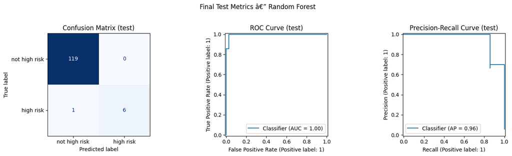

```python
# Refit best model on train+validation, evaluate once on held-out test
train_val      = pd.concat([train, validation], ignore_index=True)
X_train_val    = train_val[feature_cols]
y_train_val    = train_val["high_risk_next_year"]

final_model = clone(candidate_models[best_model_name]).fit(X_train_val, y_train_val)
final_pred  = final_model.predict(X_test)
final_prob  = final_model.predict_proba(X_test)[:, 1] if hasattr(final_model, "predict_proba") else final_pred.astype(float)

print(f"Final test evaluation - {best_model_name}")
print(classification_report(y_test, final_pred, target_names=["not high risk", "high risk"], zero_division=0))

fig, axes = plt.subplots(1, 3, figsize=(15, 4))

ConfusionMatrixDisplay(
    confusion_matrix(y_test, final_pred),
    display_labels=["not high risk", "high risk"]
).plot(ax=axes[0], cmap="Blues", colorbar=False)
axes[0].set_title("Confusion Matrix (test)")

if len(set(y_test)) > 1:
    RocCurveDisplay.from_predictions(y_test, final_prob, ax=axes[1])
    axes[1].set_title("ROC Curve (test)")
    PrecisionRecallDisplay.from_predictions(y_test, final_prob, ax=axes[2])
    axes[2].set_title("Precision-Recall Curve (test)")

plt.suptitle(f"Final Test Metrics - {best_model_name}", y=1.02)
plt.tight_layout()
plt.show()
```

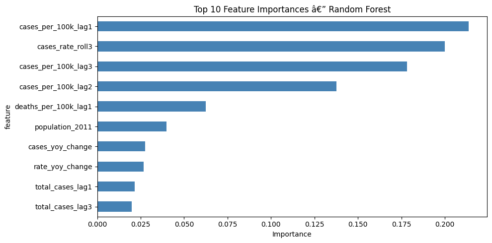

|  | feature | importance |
| --- | --- | --- |
| 0 | cases_per_100k_lag1 | 0.213563 |
| 1 | cases_rate_roll3 | 0.199963 |
| 2 | cases_per_100k_lag3 | 0.178255 |
| 3 | cases_per_100k_lag2 | 0.137683 |
| 4 | deaths_per_100k_lag1 | 0.062418 |
| 5 | population_2011 | 0.039819 |
| 6 | cases_yoy_change | 0.027622 |
| 7 | rate_yoy_change | 0.026658 |
| 8 | total_cases_lag1 | 0.021487 |
| 9 | total_cases_lag3 | 0.019967 |
| 10 | district_count | 0.019300 |
| 11 | year | 0.018265 |
| 12 | total_deaths_lag1 | 0.017779 |
| 13 | total_cases_lag2 | 0.017223 |

```
Key insight: Lag-1 to lag-3 case rates dominate -> malaria is highly autocorrelated.
Rate features outperform count features -> per-capita adjustment matters.
```

```python
# Feature importance
if best_model_name in ["Random Forest", "Gradient Boosting"]:
    importance_vals = final_model.feature_importances_
elif best_model_name == "Logistic Regression":
    importance_vals = np.abs(final_model.named_steps["m"].coef_[0])
else:
    importance_vals = np.zeros(len(feature_cols))

imp_df = (
    pd.DataFrame({"feature": feature_cols, "importance": importance_vals})
    .sort_values("importance", ascending=False)
    .reset_index(drop=True)
)
imp_df.head(10).sort_values("importance").plot(
    x="feature", y="importance", kind="barh",
    figsize=(10, 5), legend=False, color="steelblue"
)
plt.title(f"Top 10 Feature Importances - {best_model_name}")
plt.xlabel("Importance")
plt.tight_layout()
plt.show()
display(imp_df)

print("\nKey insight: Lag-1 to lag-3 case rates dominate -> malaria is highly autocorrelated.")
print("Rate features outperform count features -> per-capita adjustment matters.")
```

```python
# Predictions for selected regions in test period
pred_table = test.copy()
pred_table["predicted_high_risk"]        = final_pred
pred_table["predicted_high_risk_prob"]   = final_prob

sel_preds = pred_table[pred_table["state"].isin(SELECTED_REGIONS)][
    ["state", "year", "prediction_year", "cases_per_100k",
     "next_year_rate", "high_risk_next_year",
     "predicted_high_risk", "predicted_high_risk_prob"]
].sort_values(["state", "year"])

display(sel_preds)

print("\nKey observation:")
print("Mizoram is flagged high-risk throughout 2021-2024 (consistent with SIR R0 = 1.146).")
print("Tripura 2022 missed (prob=0.24) despite actual 2023 surge - lagged features pre-resurgence.")
```

|  | state | year | prediction_year | cases_per_100k | next_year_rate | high_risk_next_year | predicted_high_risk | predicted_high_risk_prob |
| --- | --- | --- | --- | --- | --- | --- | --- | --- |
| 462 | Mizoram | 2020 | 2021 | 706.157276 | 679.635365 | 1 | 1 | 0.709399 |
| 463 | Mizoram | 2021 | 2022 | 679.635365 | 1011.660527 | 1 | 1 | 0.771674 |
| 464 | Mizoram | 2022 | 2023 | 1011.660527 | 1640.530584 | 1 | 1 | 0.835761 |
| 465 | Mizoram | 2023 | 2024 | 1640.530584 | 392.633653 | 1 | 1 | 0.838277 |
| 504 | Odisha | 2020 | 2021 | 95.020234 | 57.435257 | 0 | 0 | 0.359701 |
| 505 | Odisha | 2021 | 2022 | 57.435257 | 53.818751 | 0 | 0 | 0.001612 |
| 506 | Odisha | 2022 | 2023 | 53.818751 | 96.011318 | 0 | 0 | 0.002500 |
| 507 | Odisha | 2023 | 2024 | 96.011318 | 20.827071 | 0 | 0 | 0.037230 |
| 630 | Tripura | 2020 | 2021 | 92.408185 | 50.681602 | 0 | 0 | 0.185291 |
| 631 | Tripura | 2021 | 2022 | 50.681602 | 347.612643 | 0 | 0 | 0.107338 |
| 632 | Tripura | 2022 | 2023 | 347.612643 | 610.030112 | 1 | 0 | 0.238061 |
| 633 | Tripura | 2023 | 2024 | 610.030112 | 45.237821 | 0 | 0 | 0.322943 |

```
Key observation:
Mizoram is flagged high-risk throughout 2021-2024 (consistent with SIR R0 = 1.146).
Tripura 2022 missed (prob=0.24) despite actual 2023 surge - lagged features pre-resurgence.
```